# Data Science 7006

Ismail Olatunji - 2315053

2024-05-14

## Data Science Assessment 2

### Restructuring my Dataset

Let’s start by importing the Weather data

We will restructure the data here

```r
getwd()
```

```
## [1] "C:/Users/user/OneDrive/Documents/DAT7006/ASS 2"
```

```r
setwd("C:/Users/user/OneDrive/Documents/DAT7006/ASS 2")

#Read the CSV file and skipp the first row
Weather_data <- read.csv("Weather Research & Forecasting Dataset 2018.csv", header = FALSE, skip = 1)

View(Weather_data)


#we set the column names as character and skipped first rol of the Weather_data
colnames(Weather_data) <- as.character(unlist(Weather_data[1, ]))
Weather_data <- Weather_data[-1, ]


View(Weather_data)

#made a subset where XLAT == 53.227 & XLONG == -1.224
Scarcliffe_data <- subset(Weather_data, XLAT == 53.227 & XLONG == -1.224)
View(Scarcliffe_data)

#I removed the first and second columns (XLAT & XLONG) in order to be able to split
#the columns to groups of 10 each as the first 10 columns are iterated all over for
#the remaining columns.

ScarcliffeXX <- Scarcliffe_data[, -(1:2)]

View(ScarcliffeXX)

#Splitted Mansfield_columns dataframe into groups with 10 columns each
Scarcliffe_columns <- split.default(ScarcliffeXX, rep(1:248, each = 10))


View(Scarcliffe_columns)

#used lapply function combine the XLAT & XLONG columns back and naming each columns
Scarcliffe_Join <- lapply(Scarcliffe_columns, function(x) {
  Scarcliffe_bind <- cbind(Scarcliffe_data[, 1:2], x)
  colnames(Scarcliffe_bind) <- c("XLAT", "XLONG", "TSK", "PSFC", "u10", "v10", "Q2", "RAINC", "RAINNC", "SNOW", "TSLB", "SMOIS")

  return(Scarcliffe_bind)
})

View(Scarcliffe_Join)

#combine the lists of data frames into one single data frame
Scarcliffemain_df <- do.call(rbind, Scarcliffe_Join)
View(Scarcliffemain_df)
```

After restructing the dataset, I will be creating new variable “Datetime” using the time as.POSIXlt

```r
#Let's generate the sequence of time stamps with 3-hour intervals
# Define the start date and time using as.POSIXlt
start_date <- as.POSIXlt("01-05-2018 00:00:00", format = "%d-%m-%Y %H:%M:%S")

nrows <- nrow(Scarcliffemain_df)
View(nrows)

# Create a sequence of timestamps with a 3-hour interval for additional rows
timestamp_sequence <- seq(start_date, by = "3 hours", length.out = nrows)

# extract the format, how we want it to be arranged
timestamp <- format(timestamp_sequence, "%d-%m-%Y %H:%M:%S")

Scarcliffemain_df$Datetime <- timestamp


# View the resulting data frame
View(Scarcliffemain_df)
head(Scarcliffemain_df)
```

```
##     XLAT  XLONG   TSK  PSFC u10  v10      Q2 RAINC RAINNC SNOW  TSLB  SMOIS
## 1 53.227 -1.224 272.1 99473 3.4 -1.8 0.00335   0.0    0.0  0.0 278.6 0.2901
## 2 53.227 -1.224 273.2 99452 4.4 -0.8 0.00389   0.0    0.0  0.0 277.5 0.2896
## 3 53.227 -1.224 278.0 99468 5.2 -0.3 0.00375   0.0      0  0.0 276.8 0.2891
## 4 53.227 -1.224 287.7 99446 4.0  3.4 0.00384   0.0    0.0  0.0 277.0 0.2874
## 5 53.227 -1.224 291.9 99359 4.6  4.9 0.00504   0.0    0.0  0.0 281.0 0.2864
## 6 53.227 -1.224 288.1 99259 6.4  5.7 0.00494   0.0    0.0  0.0 283.6 0.2849
##              Datetime
## 1 01-05-2018 00:00:00
## 2 01-05-2018 03:00:00
## 3 01-05-2018 06:00:00
## 4 01-05-2018 09:00:00
## 5 01-05-2018 12:00:00
## 6 01-05-2018 15:00:00
```

```r
tail(Scarcliffemain_df)
```

```
##       XLAT  XLONG   TSK   PSFC  u10  v10      Q2 RAINC RAINNC SNOW  TSLB  SMOIS
## 243 53.227 -1.224 288.2 100267 -1.4  0.3 0.00962   0.0    0.0    0 285.2 0.2553
## 244 53.227 -1.224 291.9 100358 -1.6 -0.3 0.01049   0.0    0.0  0.0 286.5 0.2549
## 245 53.227 -1.224 303.6 100317 -2.2 -0.2 0.01147   0.0    0.3  0.0 289.9 0.2533
## 246 53.227 -1.224 298.9 100253 -4.2 -0.4 0.01204   1.3    0.3  0.0 292.3 0.2556
## 247 53.227 -1.224 294.8 100244 -5.4  0.4 0.01152   1.3    0.3  0.0 293.1 0.2540
## 248 53.227 -1.224 286.6 100329 -2.8 -0.4 0.01006   1.3    0.3  0.0 291.7 0.2536
##                Datetime
## 243 31-05-2018 06:00:00
## 244 31-05-2018 09:00:00
## 245 31-05-2018 12:00:00
## 246 31-05-2018 15:00:00
## 247 31-05-2018 18:00:00
## 248 31-05-2018 21:00:00
```

```r
str(Scarcliffemain_df)
```

```
## 'data.frame':    248 obs. of  13 variables:
##  $ XLAT    : chr  "53.227" "53.227" "53.227" "53.227" ...
##  $ XLONG   : chr  "-1.224" "-1.224" "-1.224" "-1.224" ...
##  $ TSK     : chr  "272.1" "273.2" "278.0" "287.7" ...
##  $ PSFC    : chr  "99473" "99452" "99468" "99446" ...
##  $ u10     : chr  "3.4" "4.4" "5.2" "4.0" ...
##  $ v10     : chr  "-1.8" "-0.8" "-0.3" "3.4" ...
##  $ Q2      : chr  "0.00335" "0.00389" "0.00375" "0.00384" ...
##  $ RAINC   : chr  "0.0" "0.0" "0.0" "0.0" ...
##  $ RAINNC  : chr  "0.0" "0.0" "0" "0.0" ...
##  $ SNOW    : chr  "0.0" "0.0" "0.0" "0.0" ...
##  $ TSLB    : chr  "278.6" "277.5" "276.8" "277.0" ...
##  $ SMOIS   : chr  "0.2901" "0.2896" "0.2891" "0.2874" ...
##  $ Datetime: chr  "01-05-2018 00:00:00" "01-05-2018 03:00:00" "01-05-2018 06:00:00" "01-05-2018 09:00:00" ...
```

The data types are all in character form, I need to change all back to there proper data type

```r
#data types - change each column to the right data type

Scarcliffemain_df <- Scarcliffemain_df %>%
  mutate_at(1:12, as.numeric)
View(Scarcliffemain_df)

#convert the Datetime column to date format
Scarcliffemain_df$Datetime <- as.POSIXlt(Scarcliffemain_df$Datetime, format = "%d-%m-%Y %H:%M:%S")

# Now, recheck to be sure they are in right format now
str(Scarcliffemain_df)
```

```
## 'data.frame':    248 obs. of  13 variables:
##  $ XLAT    : num  53.2 53.2 53.2 53.2 53.2 ...
##  $ XLONG   : num  -1.22 -1.22 -1.22 -1.22 -1.22 ...
##  $ TSK     : num  272 273 278 288 292 ...
##  $ PSFC    : num  99473 99452 99468 99446 99359 ...
##  $ u10     : num  3.4 4.4 5.2 4 4.6 6.4 1.9 1.3 1.1 0.5 ...
##  $ v10     : num  -1.8 -0.8 -0.3 3.4 4.9 5.7 5.4 7.4 8.1 9.2 ...
##  $ Q2      : num  0.00335 0.00389 0.00375 0.00384 0.00504 0.00494 0.00532 0.00492 0.00509 0.00544 ...
##  $ RAINC   : num  0 0 0 0 0 0 0 0 0 0 ...
##  $ RAINNC  : num  0 0 0 0 0 0 0 0 0 0.3 ...
##  $ SNOW    : num  0 0 0 0 0 0 0 0 0 0 ...
##  $ TSLB    : num  279 278 277 277 281 ...
##  $ SMOIS   : num  0.29 0.29 0.289 0.287 0.286 ...
##  $ Datetime: POSIXlt, format: "2018-05-01 00:00:00" "2018-05-01 03:00:00" ...
```

```r
# then view
View(Scarcliffemain_df)
```

### Checking for missing values and handling them

```r
#check the number of NA we have in the whole dataset
sum(is.na(Scarcliffemain_df))
```

```
## [1] 67
```

```r
#gives us breakdown of NA in each columns
colSums(is.na(Scarcliffemain_df))
```

```
##     XLAT    XLONG      TSK     PSFC      u10      v10       Q2    RAINC
##        0        0        6        6        7        5        8        6
##   RAINNC     SNOW     TSLB    SMOIS Datetime
##        8        6        6        9        0
```

```r
#I will create a dataframe of the na_values
missing_values <- data.frame(
  Columns = c("XLAT", "XLONG", "TSK", "PSFC", "u10", "v10", "Q2", "RAINC", "RAINNC", "SNOW", "TSLB", "SMOIS", "Datetime"),
  na_count = c(0, 0, 6, 6, 7, 5, 8, 6, 8, 6, 6, 9, 0)
)
View(missing_values)

# I filter out rows with 0 NA_count as they won't be needed
missing_values1 <- missing_values[missing_values$na_count > 0, ]
missing_values1
```

```
##    Columns na_count
## 3      TSK        6
## 4     PSFC        6
## 5      u10        7
## 6      v10        5
## 7       Q2        8
## 8    RAINC        6
## 9   RAINNC        8
## 10    SNOW        6
## 11    TSLB        6
## 12   SMOIS        9
```

```r
#view filtered dataframe after removing rows/values with 0
View(missing_values1)
```

### Visualisation of the missing values

The bar chart displays the missing values in each columns

The second plot shows the percent of missing values in each column

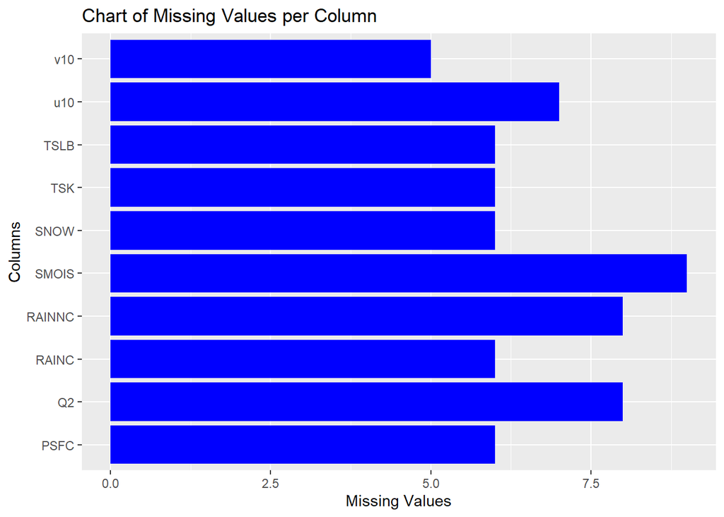

```r
#Below is the plot for our missing values on each column

ggplot(data = missing_values1, aes(x = na_count, y = Columns)) +
  geom_bar(stat = "identity", fill = "blue") +
  labs(title = "Chart of Missing Values per Column",
       x = "Missing Values",
       y = "Columns")
```

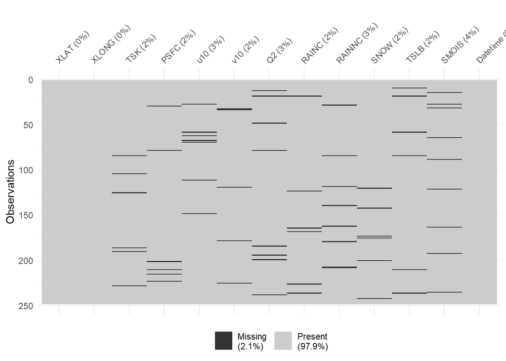

```r
#this will show us the percentage of missing values in each column
vis_miss(Scarcliffemain_df)
```

```r
View(Scarcliffemain_df)  # this gives us overview of all our missing values
```

### Handling of missing values

na.approx function was called to action here to handle the NA values

```r
# Let's handle all missing values column by column
colSums(is.na(Scarcliffemain_df))
```

```
##     XLAT    XLONG      TSK     PSFC      u10      v10       Q2    RAINC
##        0        0        6        6        7        5        8        6
##   RAINNC     SNOW     TSLB    SMOIS Datetime
##        8        6        6        9        0
```

```r
# na.approx function will be used to interpolate NA values in each column
Scarcliffemain_df1 <- Scarcliffemain_df %>%
  mutate(across(c(TSK, PSFC, u10, v10, Q2, RAINC, RAINNC, SNOW, TSLB, SMOIS), na.approx))

View(Scarcliffemain_df1)

# Let's recheck to be sure we don't have missing values anymore
# All missing values are now handled, which means we have no missing value anymore
colSums(is.na(Scarcliffemain_df1))
```

```
##     XLAT    XLONG      TSK     PSFC      u10      v10       Q2    RAINC
##        0        0        0        0        0        0        0        0
##   RAINNC     SNOW     TSLB    SMOIS Datetime
##        0        0        0        0        0
```

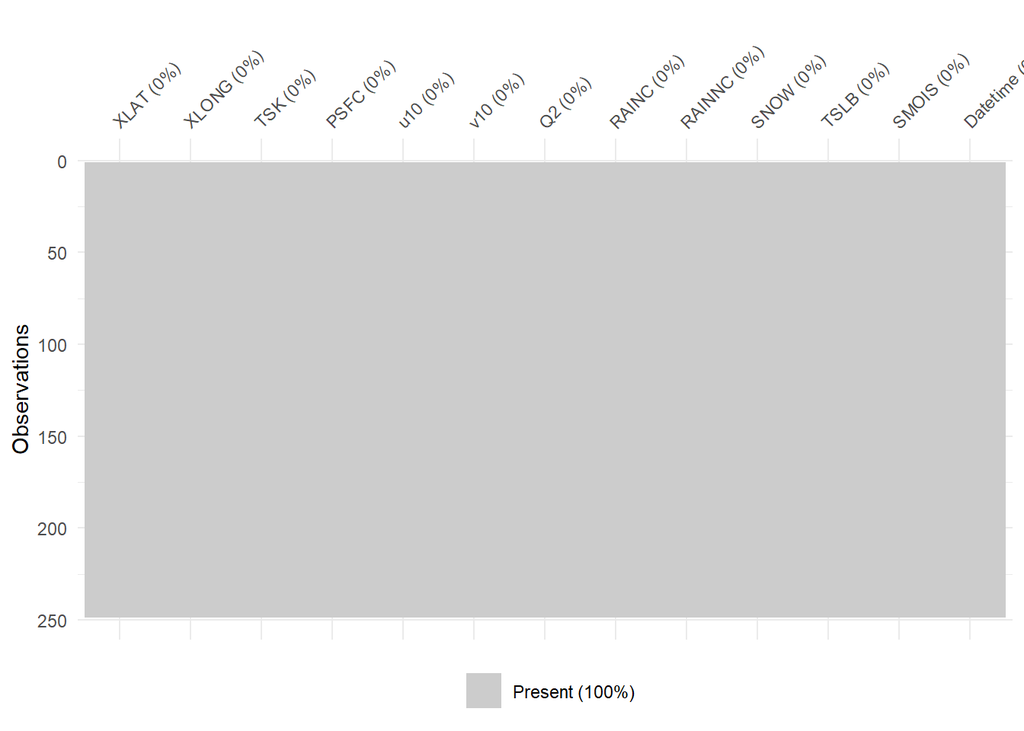

```r
#let's recheck our missing values percentage again
vis_miss(Scarcliffemain_df1)
```

```r
#the visualisation above shows that we don't have any missing value anymore
```

### Calculate Windspeed Using X and Y Components of Wind (u10, v10)

The Windspeed variable will be added to the dataset

```r
# Calculate wind speed using the Pythagorean theorem, I will use mutate function to create a new
# column "Windspeed"

Scarcliffemain_df1 <- Scarcliffemain_df1 %>%
  mutate(Windspeed = sqrt(u10^2 + v10^2))
head(Scarcliffemain_df1)
```

```
##     XLAT  XLONG   TSK  PSFC u10  v10      Q2 RAINC RAINNC SNOW  TSLB  SMOIS
## 1 53.227 -1.224 272.1 99473 3.4 -1.8 0.00335     0      0    0 278.6 0.2901
## 2 53.227 -1.224 273.2 99452 4.4 -0.8 0.00389     0      0    0 277.5 0.2896
## 3 53.227 -1.224 278.0 99468 5.2 -0.3 0.00375     0      0    0 276.8 0.2891
## 4 53.227 -1.224 287.7 99446 4.0  3.4 0.00384     0      0    0 277.0 0.2874
## 5 53.227 -1.224 291.9 99359 4.6  4.9 0.00504     0      0    0 281.0 0.2864
## 6 53.227 -1.224 288.1 99259 6.4  5.7 0.00494     0      0    0 283.6 0.2849
##              Datetime Windspeed
## 1 2018-05-01 00:00:00  3.847077
## 2 2018-05-01 03:00:00  4.472136
## 3 2018-05-01 06:00:00  5.208647
## 4 2018-05-01 09:00:00  5.249762
## 5 2018-05-01 12:00:00  6.720863
## 6 2018-05-01 15:00:00  8.570298
```

### Dropping of Columns

I will be dropping u10, v10, RAINNC, SNOW, SMOIS columns, they are not needed for my analysis

```r
Scarcliffenew_df <- Scarcliffemain_df1 %>%
  select(-u10, -v10, -RAINNC, -SNOW, -SMOIS)


# We are now left with 9 columns, XLAT, XLONG, TSK, PSFC, Q2, RAINC, TSLB, Datetime, Windspeed
```

### Conversion of Units

I will be doing conversion of some parametres to common UK standard

```r
Scarcliffenew_df <- Scarcliffenew_df %>%
  mutate(TSK = TSK - 273.15,         # conversion of TSK from Kelvin to Celsius
         TSLB = TSLB - 273.15,       # conversion of TSLB from Kelvin to Celsius
         PSFC = PSFC / 100,          # conversion of PSFC from Pascal to hPa
         Q2 = Q2 * 1000)             # conversion of Q2 from kg/kg to g/kg

head(Scarcliffenew_df)
```

```
##     XLAT  XLONG   TSK   PSFC   Q2 RAINC  TSLB            Datetime Windspeed
## 1 53.227 -1.224 -1.05 994.73 3.35     0  5.45 2018-05-01 00:00:00  3.847077
## 2 53.227 -1.224  0.05 994.52 3.89     0  4.35 2018-05-01 03:00:00  4.472136
## 3 53.227 -1.224  4.85 994.68 3.75     0  3.65 2018-05-01 06:00:00  5.208647
## 4 53.227 -1.224 14.55 994.46 3.84     0  3.85 2018-05-01 09:00:00  5.249762
## 5 53.227 -1.224 18.75 993.59 5.04     0  7.85 2018-05-01 12:00:00  6.720863
## 6 53.227 -1.224 14.95 992.59 4.94     0 10.45 2018-05-01 15:00:00  8.570298
```

```r
tail(Scarcliffenew_df)
```

```
##       XLAT  XLONG   TSK    PSFC    Q2 RAINC  TSLB            Datetime Windspeed
## 243 53.227 -1.224 15.05 1002.67  9.62   0.0 12.05 2018-05-31 06:00:00  1.431782
## 244 53.227 -1.224 18.75 1003.58 10.49   0.0 13.35 2018-05-31 09:00:00  1.627882
## 245 53.227 -1.224 30.45 1003.17 11.47   0.0 16.75 2018-05-31 12:00:00  2.209072
## 246 53.227 -1.224 25.75 1002.53 12.04   1.3 19.15 2018-05-31 15:00:00  4.219005
## 247 53.227 -1.224 21.65 1002.44 11.52   1.3 19.95 2018-05-31 18:00:00  5.414795
## 248 53.227 -1.224 13.45 1003.29 10.06   1.3 18.55 2018-05-31 21:00:00  2.828427
```

### Outliers

#### 1. Detecting outliers in TSK column using IQR

What we need to do next is to detect outliers and handle them appropriately

```r
quantile(Scarcliffenew_df$TSK)
```

```
##     0%    25%    50%    75%   100%
## -1.050  8.725 12.150 19.175 30.450
```

```r
summary(Scarcliffenew_df$TSK)
```

```
##    Min. 1st Qu.  Median    Mean 3rd Qu.    Max.
##  -1.050   8.725  12.150  13.673  19.175  30.450
```

```r
TSK_IQR <- IQR(Scarcliffenew_df$TSK) #this is simply Q3 - Q1, Q3 = 19.175 and Q1 = 8.725
TSK_IQR
```

```
## [1] 10.45
```

```r
#Q3 <- quantile(Scarcliffenew_df$TSK, 0.75)
#Q1 <- quantile(Scarcliffenew_df$TSK, 0.25)

#let's get our upper and lower bounds in TSK column
upper_bound <- quantile(Scarcliffenew_df$TSK, 0.75) + 1.5 * TSK_IQR
upper_bound # upper bound is 34.85 which means, any figure above this is an outlier
```

```
##   75%
## 34.85
```

```r
lower_bound <- quantile(Scarcliffenew_df$TSK, 0.25) - 1.5 * TSK_IQR
lower_bound
```

```
##   25%
## -6.95
```

```r
#lower bound is -6.95, any value below the lower bound is an outlier

#Remove outliers

TSK_outliers <- Scarcliffenew_df[Scarcliffenew_df$TSK < lower_bound | Scarcliffenew_df$TSK > upper_bound]
print(TSK_outliers)
```

```
## data frame with 0 columns and 248 rows
```

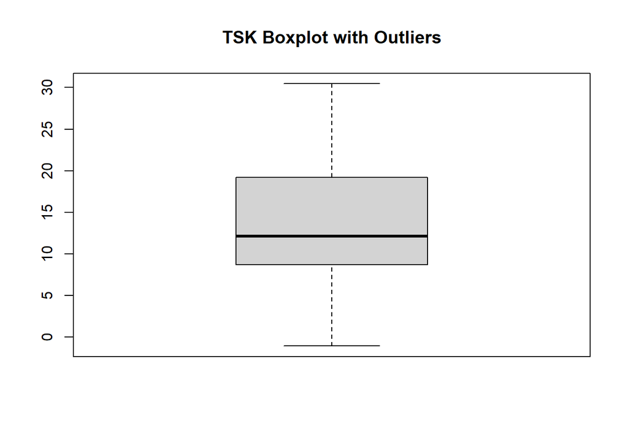

```r
boxplot(Scarcliffenew_df$TSK, main = "TSK Boxplot with Outliers")
```

```r
#From the IQR detection method and the boxplot visualisation, it is clear that TSK column has no outlier
```

### 2. Detecting and handling of outliers in PSFC column using Tukey’s Fences method

```r
PSFC_outliers <- boxplot.stats(Scarcliffenew_df$PSFC)$out
print(PSFC_outliers)
```

```
## [1] 989.54 987.48 985.84 986.93 989.90
```

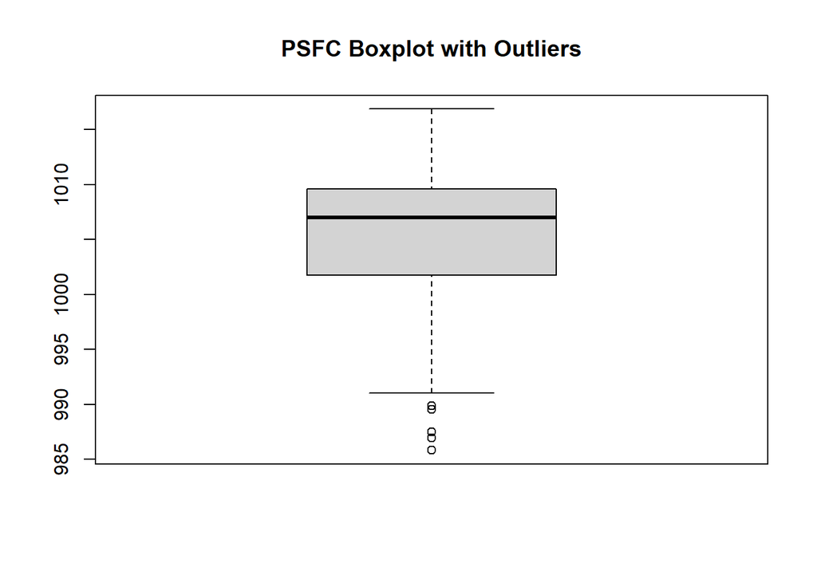

```r
boxplot(Scarcliffenew_df$PSFC, main = "PSFC Boxplot with Outliers")
```

```r
#### from the visualisation, it is clear we have 5 outliers in PSFC Column, which 989.54 987.48 985.84 986.93 989.90
```

### 3. Detecting and handling outliers in Q2 column

```r
Q2_outliers <- boxplot.stats(Scarcliffenew_df$Q2)$out
print(Q2_outliers)
```

```
## numeric(0)
```

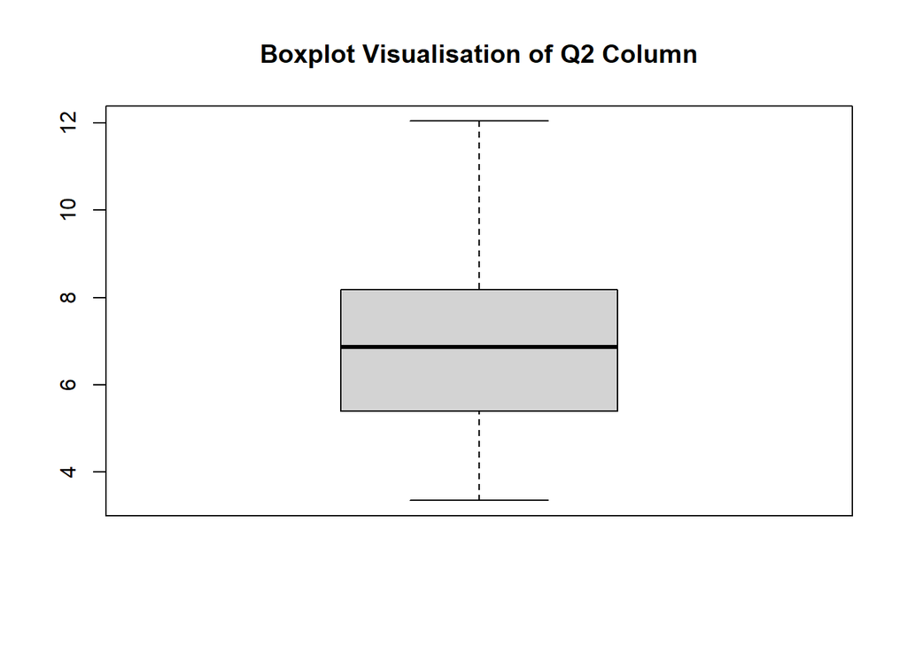

```r
boxplot(Scarcliffenew_df$Q2, main = "Boxplot Visualisation of Q2 Column")
```

```r
# No outliers detected in Q2 Column
```

### 4. Detecting and handling outliers in RAINC column

```r
RAINC_outliers <- boxplot.stats(Scarcliffenew_df$RAINC)$out
print(RAINC_outliers)
```

```
##  [1] 0.1 0.1 0.1 0.1 0.1 0.8 0.1 0.1 0.1 0.1 0.1 0.1 0.1 0.1 0.4 0.4 0.4 0.4 1.3
## [20] 1.3 1.3
```

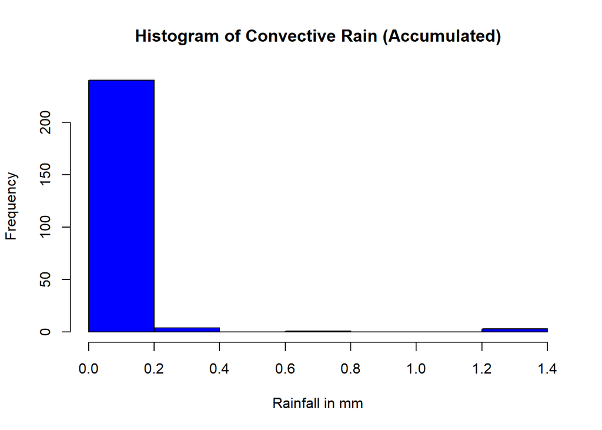

```r
# Histogram of RAINC values
hist(Scarcliffenew_df$RAINC, main = "Histogram of Convective Rain (Accumulated)", xlab = "Rainfall in mm", col = "blue")
```

```r
# Leaving the outliers in order to ensure that the analysis reflects the true
# variability in rainfall patterns.
```

### 5. Detecting and handling outliers in TSLB column

```r
TSLB_outliers <- boxplot.stats(Scarcliffenew_df$TSLB)$out
print(TSLB_outliers)
```

```
## [1] 3.65
```

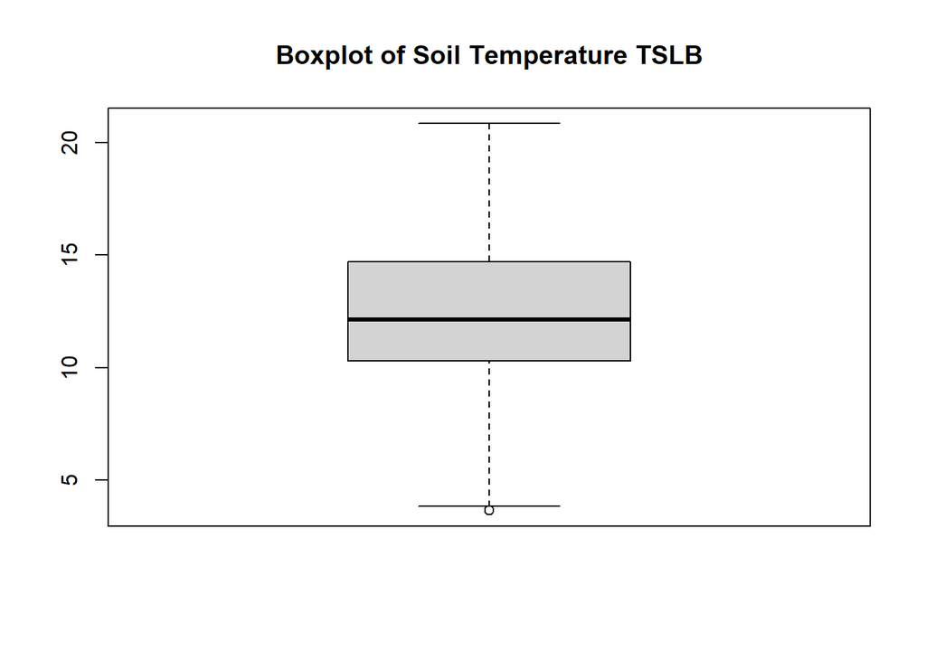

```r
boxplot(Scarcliffenew_df$TSLB, main = "Boxplot of Soil Temperature TSLB")
```

### 6. Detecting and handling outliers in Windspeed column

```r
Windspeed_outliers <- boxplot.stats(Scarcliffenew_df$Windspeed)$out
print(Windspeed_outliers)
```

```
## [1] 8.570298 8.174350 9.213577 9.374433
```

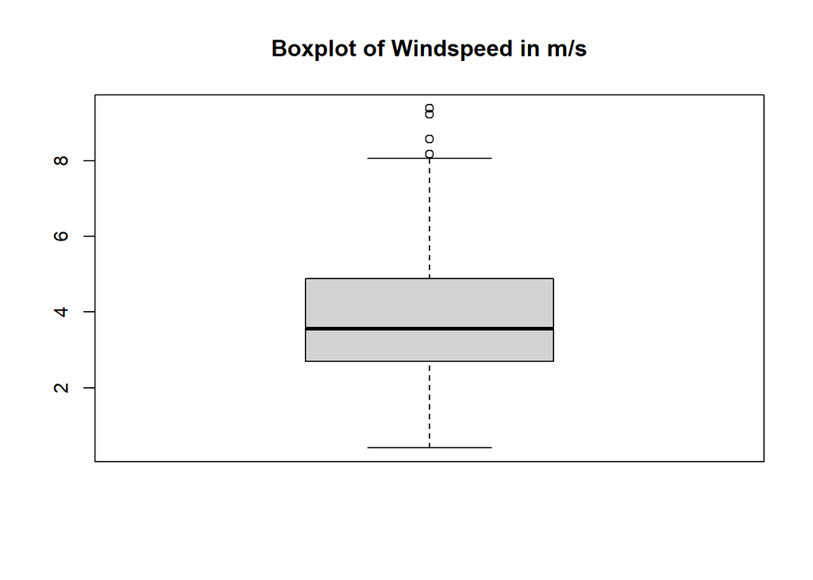

```r
boxplot(Scarcliffenew_df$Windspeed, main = "Boxplot of Windspeed in m/s")
```

```r
# my outliers here are 8.570298 8.174350 9.213577 9.374433, but I will not be dropping any of them
```

After getting outliers in some columns, I decided not to remove them because they are true outliers; natural variations.They are genuine observations and very vital.

# STATISTICAL ANALYSIS

### Univariate Analysis

I will be doing Univariate analysis of Convective rain (Accumulated precipitation) - RAINC

To determine the RAINC central tendency and distribution, Summary() function in R will give us the basic descriptive statistical analysis such as the minimum value, 1st quartile, Mean, Median, 3rd quartile and the Maximum number.

Histogram will also be used to visualise RAINC frequency distribution to understand its distribution shape

Additionally, I will use Shapiro-Wilk to test the normality of RAINC to determine if it follow a normal distribution.

```r
summary(Scarcliffenew_df$RAINC)
```

```
##    Min. 1st Qu.  Median    Mean 3rd Qu.    Max.
## 0.00000 0.00000 0.00000 0.03065 0.00000 1.30000
```

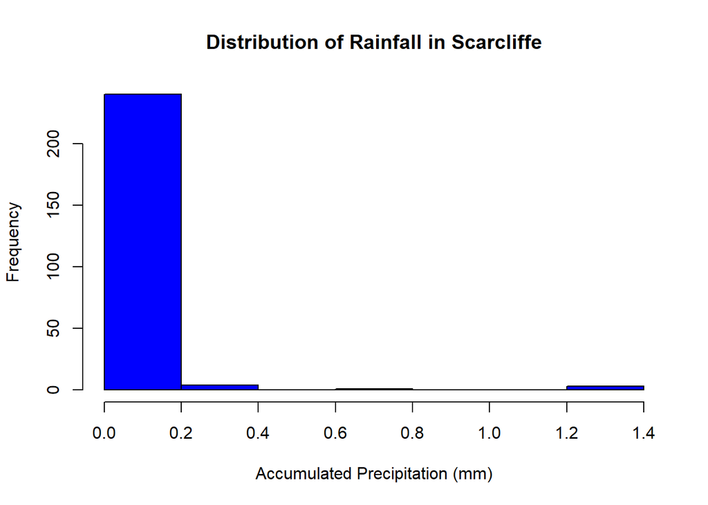

```r
hist(Scarcliffemain_df1$RAINC,
     main = "Distribution of Rainfall in Scarcliffe",
     xlab = "Accumulated Precipitation (mm)", col = "blue")
```

```r
# Shapiro-Wilk normality test

shapiro.test(Scarcliffenew_df$RAINC)
```

```
##
##  Shapiro-Wilk normality test
##
## data:  Scarcliffenew_df$RAINC
## W = 0.19033, p-value < 2.2e-16
```

1. The histogram shows a highly skewed distribution with a significant peak at 0.0 mm, indicating that the most frequent observation is no precipitation. There are a few smaller bars to the right, showing that there are fewer occurrences of higher precipitation values. This distribution suggests that over the period or area studied, dry conditions are much more common than wet conditions. The shape of the distribution, heavily skewed with a long tail to the right, is typical for precipitation data, where many dry days and a few very wet days are common.
2. The Shapiro-Wilk test results show that RAINC deviates from a normal distribution. This indicates that the test and model hypotheses based on normally distributed data are not met. It is very obvious to arrive at this conclusion mere looking at the histogram

# Bivariate Analysis

Let’s explore the relationship between temperature and Soil Temperature in Scarcliffe by plotting a scatter plot.

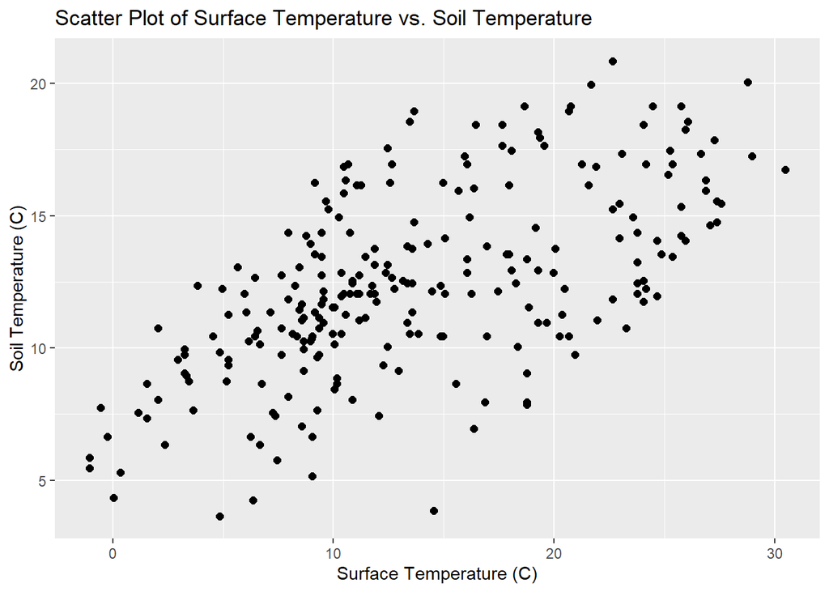

```r
ggplot(data = Scarcliffenew_df, aes(x = TSK, y = TSLB)) +
  geom_point(size = 2) +
  labs(x = "Surface Temperature (C)", y = "Soil Temperature (C)", title = "Scatter Plot of Surface Temperature vs. Soil Temperature")
```

```r
# Check for Pearson's correlation coefficient
cor.test(Scarcliffenew_df$TSK, Scarcliffenew_df$TSLB, method = "pearson")
```

```
##
##  Pearson's product-moment correlation
##
## data:  Scarcliffenew_df$TSK and Scarcliffenew_df$TSLB
## t = 12.233, df = 246, p-value < 2.2e-16
## alternative hypothesis: true correlation is not equal to 0
## 95 percent confidence interval:
##  0.5311261 0.6869448
## sample estimates:
##      cor
## 0.615004
```

The plot above shows a scatter plot of surface temperature on the x-axis plotted against the soil temperature on the y-axis. The scattered data points on the graph clearly demonstrate a pattern that shows a rise in soil temperature in relation to surface temperature.

Pearson correlation test shows the direction and strength of linear connection between surface temperature and soil temperature. From the result, it means surface temperature and soil temperature have strong correlation in the positive direction.

# Multivariate Analysis

To investigate the correlations between a dependent variable, surface temperature (TSK) and several independent variables such as, surface pressure PSFC, humidity Q2, precipitation RAINC, soil temperature TSLB, and wind speed Windspeed), we can design a multiple linear regression model.

```r
# Fit a multiple linear regression model

mlr_model <- lm(TSK ~ PSFC + Q2 + RAINC + TSLB + Windspeed, data = Scarcliffenew_df)

summary(mlr_model)
```

```
##
## Call:
## lm(formula = TSK ~ PSFC + Q2 + RAINC + TSLB + Windspeed, data = Scarcliffenew_df)
##
## Residuals:
##    Min     1Q Median     3Q    Max
## -8.652 -4.278 -1.309  4.097 14.259
##
## Coefficients:
##              Estimate Std. Error t value Pr(>|t|)
## (Intercept) -32.72972   58.89133  -0.556   0.5789
## PSFC          0.02587    0.05845   0.443   0.6585
## Q2            1.09054    0.26565   4.105 5.53e-05 ***
## RAINC        -3.51348    2.29414  -1.532   0.1270
## TSLB          0.92522    0.13390   6.910 4.26e-11 ***
## Windspeed     0.38055    0.21321   1.785   0.0755 .
## ---
## Signif. codes:  0 '***' 0.001 '**' 0.01 '*' 0.05 '.' 0.1 ' ' 1
##
## Residual standard error: 5.502 on 242 degrees of freedom
## Multiple R-squared:  0.4263, Adjusted R-squared:  0.4144
## F-statistic: 35.96 on 5 and 242 DF,  p-value: < 2.2e-16
```

This study provides insight into the individual and combined impacts of the independent variables on the dependent variable, as well as the overall model fit and significance.

# MACHINE LEARNING

### 1. Multiple Linear Regression

We will start by spliting the dataset into separate training and testing sets. This allows training the model on one portion of the data and evaluate its performance on the unseen testing data.

```r
# Set seed for reproducibility
set.seed(123)

# Split the data into training and testing sets

split <- sample.split(Scarcliffenew_df, SplitRatio = 0.8)
train_set <- subset(Scarcliffenew_df, split == TRUE)
test_set <- subset(Scarcliffenew_df, split == FALSE)


# Select dependent and independent variable for training data
X_train <- train_set[, c("PSFC", "Q2", "RAINC", "TSLB", "Windspeed")]
y_train <- train_set$TSK


# Fit the multiple linear regression model
mlr_model <- lm(TSK ~ ., data = train_set[, c("PSFC", "Q2", "RAINC", "TSLB", "Windspeed", "TSK")])

# Select dependent and independent variables for testing data
X_test <- test_set[, c("PSFC", "Q2", "RAINC", "TSLB", "Windspeed")]
y_test <- test_set$TSK

# Make predictions on the test data
mlr_pred <- predict(mlr_model, newdata = X_test)
mlr_pred
```

```
##         5         8        14        17        23        26        32        35
##  7.808564  9.706280 10.876883  5.329902 13.695553  6.928710 15.993053  8.457605
##        41        44        50        53        59        62        68        71
## 13.636732 15.589412 12.573478 20.840746 14.932378 21.226263 11.666760 11.215684
##        77        80        86        89        95        98       104       107
## 12.448851 10.505216 14.034424 10.848933 13.134186 11.299768 12.424965  5.899376
##       113       116       122       125       131       134       140       143
## 10.518766 10.302025 14.937267 12.118649  5.676134 13.263883  7.210499 14.528662
##       149       152       158       161       167       170       176       179
## 15.631526 15.803926 19.107785 13.454054 20.796427 11.142632 14.304174 11.010982
##       185       188       194       197       203       206       212       215
## 12.500611 13.505834 13.852906 13.869257 13.260276 21.216093 18.735250 22.546840
##       221       224       230       233       239       242       248
## 19.246356 21.250866 22.639102 15.750743 16.971768 14.147391 19.889894
```

```r
# Calculate RMSE
rmse <- sqrt(mean((y_test - mlr_pred)^2))
rmse
```

```
## [1] 5.4573
```

```r
# Calculate MAE
mae <- mean(abs(y_test - mlr_pred))
print(paste("MAE:", mae))
```

```
## [1] "MAE: 4.62373534213109"
```

## Let’s do series of testing on the model

Let’s start by analysing the residuals (the discrepancies between actual and expected values) to look for trends or violations of assumptions. This plot is a set of diagnostic charts typically used to analyse the assumptions and performance of a linear regression model

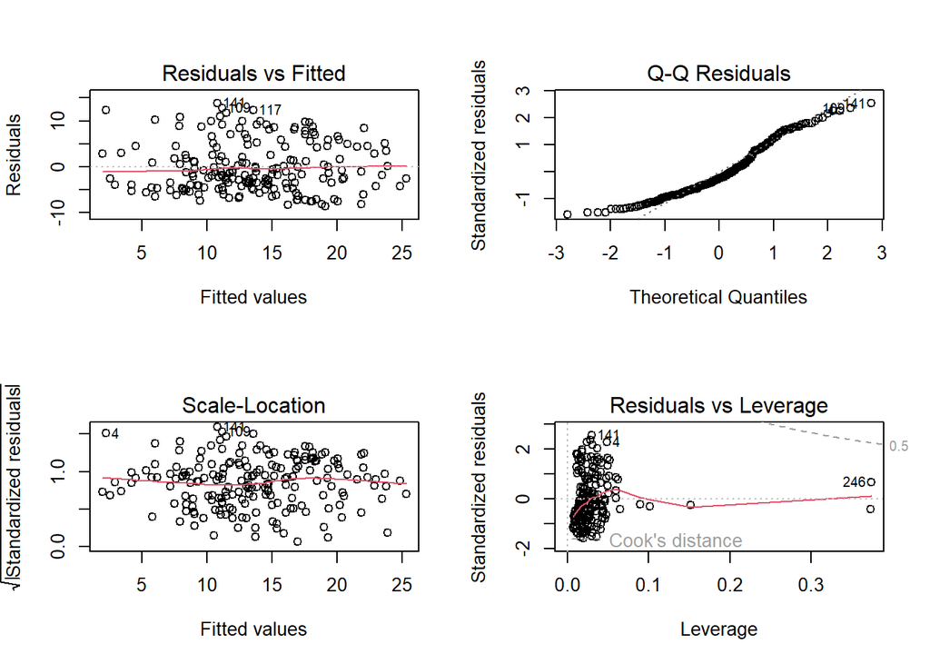

```r
# Let's do some testing on the model
par(mfrow = c(2,2))
plot(mlr_model)
```

### Check for Linearity

In this situation, the p-value of 0.916 is bigger than the generally accepted significance level of 0.05. This means that we fail to reject the null hypothesis of linearity. In other words, based on the Rainbow Test, there is no evidence to suggest that the linearity assumption is violated in the multiple linear regression model

```r
install.packages("lmtest") # install and load lmtest package
library(lmtest)

raintest(mlr_model)
```

```
##
##  Rainbow test
##
## data:  mlr_model
## Rain = 0.75159, df1 = 97, df2 = 90, p-value = 0.916
```

```r
# p-value is 0.916 which interprets that my model is fit and has a linear relationship
```

### Check for Heteroscedasticity

The p-value = 0.76837, which is higher than the typical significance level of 0.05. This indicates that the constant variance (homoscedasticity) null hypothesis cannot be rejected.

```r
install.packages("car")  # install and load the "car" package
library(car)

ncvTest(mlr_model)
```

```
## Non-constant Variance Score Test
## Variance formula: ~ fitted.values
## Chisquare = 0.08673491, Df = 1, p = 0.76837
```

```r
# p-value is 0.76837, it means no heteroscedasticity
```